# Dream the Road — Tiny Dreamer for Highway-env

**Student:** Jonesh Shrestha  
**Course / Section:** CSC 580 - Artificial Intelligence II, Section 801  
**Assignment:** Final Project - World Model (Dreamer V1)  
**Date:** March 19, 2026  
**AI Tools Consulted:** ChatGPT, Claude Code

## Project Overview

This notebook implements a **Dreamer V1**-style world model for the **highway-v0** environment from [Highway-env](https://highway-env.farama.org/environments/highway/).

**Goal:** Learn a latent dynamics model of highway driving from pixel observations, then train an actor-critic policy entirely inside the learned "dream" (latent imagination), and finally deploy the policy in the real environment.

### Architecture (Dreamer V1)

| Component | Role |
| --- | --- |
| **ConvEncoder** | Compress 64x64 RGB frames into a 1536-d embedding (depth=48) |
| **StateEncoder** | Encode auxiliary proprioceptive state [speed, cos_h, sin_h] into 64-d |
| **RSSM** | Recurrent State-Space Model — deterministic GRU(200) + stochastic Gaussian(30) |
| **ConvDecoder** | Reconstruct frames from the 230-d latent feature |
| **StateDecoder** | Predict proprioceptive state from latent — ensures latent encodes heading/speed |
| **Reward Model** | Predict scalar reward from the latent feature |
| **Actor** | Output continuous actions (acceleration + steering) via tanh-Normal |
| **Critic** | Estimate state value for lambda-return targets |

```python
import os
import random
import warnings

# Suppress noisy warnings from pygame / rendering on headless servers
os.environ['PYGAME_HIDE_SUPPORT_PROMPT'] = '1'
warnings.filterwarnings('ignore', category=UserWarning)

import numpy as np
import torch
import torch.nn as nn
import torch.nn.functional as F
import torch.distributions as td
import torch.optim as optim

import gymnasium as gym
import highway_env  # registers highway-v0

import cv2
import imageio
import matplotlib.pyplot as plt
from tqdm.auto import tqdm
from IPython.display import Video, display

# ── Device & reproducibility ──
if torch.cuda.is_available():
    gpu_idx = 3 if torch.cuda.device_count() > 1 else 0
    DEVICE = torch.device(f'cuda:{gpu_idx}')
else:
    DEVICE = torch.device('cpu')
SEED = 42
torch.manual_seed(SEED)
np.random.seed(SEED)
random.seed(SEED)
print(f'Device: {DEVICE}')
if DEVICE.type == 'cuda':
    print(f'GPU: {torch.cuda.get_device_name(DEVICE)}')
```

```
Device: cuda:3
GPU: NVIDIA A100 80GB PCIe
```

```python
# ── Architecture ──
IMG_SIZE     = 64       # input image resolution (square)
STOCH_DIM    = 30       # stochastic latent dimension
DETER_DIM    = 200      # deterministic (GRU) hidden size
CNN_DEPTH    = 48       # base convolution width for the 64x64 image encoder/decoder
CNN_EMBED    = 8 * CNN_DEPTH * 2 * 2   # encoder output: 1536 for depth=48
STATE_DIM    = 3        # auxiliary proprioceptive state: [speed_norm, cos_h, sin_h]
STATE_EMBED  = 64       # MLP output dimension for state encoder
EMBED_DIM    = CNN_EMBED + STATE_EMBED  # 1600 total embedding (pixel + state)
FEAT_DIM     = DETER_DIM + STOCH_DIM   # 230
ACTION_DIM   = 2        # continuous: [acceleration, steering]
DENSE_DIM    = 400      # hidden units in MLP heads

# ── Training ──
MODEL_LR     = 6e-4     # world-model learning rate
ACTOR_LR     = 8e-5     # actor learning rate
CRITIC_LR    = 8e-5     # critic learning rate
GRAD_CLIP    = 100.0    # global gradient-norm clip
FREE_NATS    = 0.1      # free-nats floor; avoids over-penalising very small KL values
BATCH_SIZE   = 32       # sequences per gradient step
SEQ_LEN      = 25       # sequence length for world-model training
IMAGINE_HORIZON = 15    # imagination rollout length for actor-critic
GAMMA        = 0.95     # discount factor for lambda-returns
LAMBDA_      = 0.95     # GAE lambda for lambda-returns
EXPL_NOISE   = 0.05     # exploration noise std (low to avoid corrupting heading)

# ── Action shaping in imagination ──
STEER_PENALTY = 0.5     # penalise large steering magnitudes in imagination to discourage spinning
ACCEL_BONUS   = 0.0     # no extra acceleration shaping; speed incentive comes from the task reward

# ── Steering safety ──
MAX_STEER = 0.3  # clamp the normalized steering command before the environment maps it

# ── Loop control ──
PREFILL_EPISODES   = 30     # random episodes to seed the buffer
TRAIN_ITERS        = 200    # outer training iterations
TRAIN_STEPS        = 50     # gradient steps per iteration
EVAL_EVERY         = 20     # evaluate every 20 iterations (frequent enough to catch peaks)
EVAL_EPISODES      = 5      # episodes per evaluation
BUFFER_CAPACITY    = 100_000  # replay buffer capacity

# ── Output paths ──
VIDEO_DIR = 'videos'
os.makedirs(VIDEO_DIR, exist_ok=True)

print(f'CNN_EMBED  = {CNN_EMBED}')
print(f'EMBED_DIM  = {EMBED_DIM}  (CNN {CNN_EMBED} + State {STATE_EMBED})')
print(f'FEAT_DIM   = {FEAT_DIM}   (DETER_DIM + STOCH_DIM)')
print(f'FREE_NATS  = {FREE_NATS}')
print(f'STEER_PENALTY  = {STEER_PENALTY}')
print(f'MAX_STEER      = {MAX_STEER}')
print(f'EXPL_NOISE     = {EXPL_NOISE}')
print(f'Total gradient steps planned: {TRAIN_ITERS * TRAIN_STEPS:,}')
```

```
CNN_EMBED  = 1536
EMBED_DIM  = 1600  (CNN 1536 + State 64)
FEAT_DIM   = 230   (DETER_DIM + STOCH_DIM)
FREE_NATS  = 0.1
STEER_PENALTY  = 0.5
MAX_STEER      = 0.3
EXPL_NOISE     = 0.05
Total gradient steps planned: 10,000
```

## 1. Environment Setup

We configure **highway-v0** with:

- `render_mode="rgb_array"` so we can capture pixel observations via `env.render()`
- `ContinuousAction` — two floats in [-1, 1] controlling acceleration and steering
- 4 lanes, 50 other vehicles, 40-second episodes at 5 Hz policy frequency

A heading penalty wrapper is added to discourage spinning. In stock highway-v0, the reward uses forward speed speed * cos(heading) together with lane/collision terms, and the result may then be normalized. Because of that setup, strongly misaligned driving is not penalized as directly as desired for this project, so the agent can discover unstable turning behavior. The wrapper subtracts 0.5 * (1 - cos(heading)), which is 0 when the vehicle points forward, 1 when it is sideways, and 2 when it points backward. These are deliberate project-specific overrides on top of the default highway-v0 setup.

```python
class HeadingRewardWrapper(gym.Wrapper):
    """
    Wrap highway-v0 with an extra heading-alignment penalty.

    The stock reward uses forward speed `speed * cos(heading)` together with lane
    and collision terms. With normalized rewards, misaligned driving can still
    receive a moderately positive reward, so the agent may discover spinning
    behavior. This wrapper subtracts `HEADING_PENALTY * (1 - cos(heading))`,
    which penalises sideways and backward headings while leaving straight-ahead
    driving unchanged.
    """
    HEADING_PENALTY = 0.5   # weight for the heading penalty term

    def step(self, action):
        obs, reward, term, trunc, info = self.env.step(action)
        heading = self.unwrapped.vehicle.heading
        heading_dev = 1.0 - np.cos(heading)    # 0 at forward, 1 at sideways, 2 at backwards
        reward -= self.HEADING_PENALTY * heading_dev
        return obs, reward, term, trunc, info


def make_env(seed=SEED):
    """Create and return a configured highway-v0 environment with heading penalty."""
    env = gym.make('highway-v0', render_mode='rgb_array', config={
        'action': {
            'type': 'ContinuousAction',
            'steering_range': (-0.3, 0.3),   # limit at env level (matches MAX_STEER)
        },
        'lanes_count': 4,
        'vehicles_count': 50,
        'duration': 40,
        'policy_frequency': 5,
        'simulation_frequency': 15,
        # ── Reward tuning for collision avoidance ──
        'collision_reward': -5,          # default -1 is too weak
        'normalize_reward': False,       # default True squashes collision to ~0
        'right_lane_reward': 0.0,        # disable lane preference
        # offroad_terminal defaults to False — keep it so random prefill
        # episodes are long enough to seed the replay buffer properly
    })
    env = HeadingRewardWrapper(env)
    env.reset(seed=seed)
    return env


def get_obs(env):
    """Capture an RGB frame from the renderer and resize to IMG_SIZE x IMG_SIZE."""
    frame = env.render()                              # (H, W, 3) uint8
    frame = cv2.resize(frame, (IMG_SIZE, IMG_SIZE),
                       interpolation=cv2.INTER_AREA)  # (64, 64, 3) uint8
    return frame


def get_state(env):
    """Extract auxiliary proprioceptive state: [speed_norm, cos_h, sin_h]."""
    vehicle = env.unwrapped.vehicle
    speed_norm = vehicle.speed / 40.0   # normalise to ~[0, 1]
    heading = vehicle.heading
    return np.array([speed_norm, np.cos(heading), np.sin(heading)], dtype=np.float32)


def preprocess(obs_uint8):
    """uint8 numpy (H,W,3) -> float32 tensor (3,H,W) in [-0.5, 0.5]."""
    return torch.tensor(obs_uint8, dtype=torch.float32).permute(2, 0, 1) / 255.0 - 0.5


def postprocess(tensor):
    """float32 tensor (3,H,W) in [-0.5,0.5] -> uint8 numpy (H,W,3)."""
    img = (tensor.detach().cpu().permute(1, 2, 0).numpy() + 0.5) * 255.0
    return np.clip(img, 0, 255).astype(np.uint8)
```

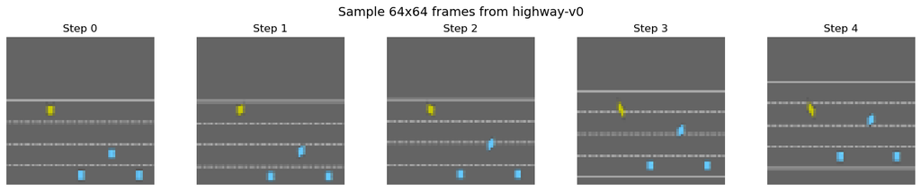

```
Action space: Box(-1.0, 1.0, (2,), float32)
```

```python
# Quick sanity check: render a few frames with random actions
env = make_env()
env.reset(seed=SEED)

sample_frames = []
for _ in range(5):
    sample_frames.append(get_obs(env))
    env.step(env.action_space.sample())

fig, axes = plt.subplots(1, 5, figsize=(15, 3))
for i, (ax, frame) in enumerate(zip(axes, sample_frames)):
    ax.imshow(frame)
    ax.set_title(f'Step {i}')
    ax.axis('off')
plt.suptitle('Sample 64x64 frames from highway-v0', fontsize=14)
plt.tight_layout()
plt.show()
env.close()
print(f'Action space: {make_env().action_space}')
```

## 2. Replay Buffer

Episodes are stored as dicts of numpy arrays. Observations stay as **uint8** to save memory and are converted to float tensors only when sampled for training.

Each episode stores `T` observations, `T-1` actions, and `T-1` rewards (the first observation is the initial frame before any action is taken).

```python
class ReplayBuffer:
    """Episode-based replay buffer storing pixel obs, auxiliary states, actions, rewards."""

    def __init__(self, capacity=BUFFER_CAPACITY):
        self.capacity = capacity
        self.episodes = []
        self.total_steps = 0

    def add(self, episode):
        """
        Add an episode dict with keys:
            observations : (T, 64, 64, 3) uint8
            states       : (T, STATE_DIM) float32   — auxiliary proprioceptive state
            actions      : (T-1, 2) float32
            rewards      : (T-1,) float32
        """
        self.episodes.append(episode)
        self.total_steps += len(episode['rewards'])
        while self.total_steps > self.capacity and len(self.episodes) > 1:
            removed = self.episodes.pop(0)
            self.total_steps -= len(removed['rewards'])

    def _valid_episodes(self, seq_len):
        return [e for e in self.episodes if len(e['rewards']) >= seq_len]

    def sample(self, batch_size, seq_len):
        """
        Sample a batch of contiguous subsequences.

        Returns dict of tensors on DEVICE:
            obs     : (B, L, 3, 64, 64)
            states  : (B, L, STATE_DIM)
            actions : (B, L, 2)
            rewards : (B, L)
        """
        valid = self._valid_episodes(seq_len)
        if not valid:
            max_len = max(len(e['rewards']) for e in self.episodes)
            seq_len = max(1, max_len)
            valid = self._valid_episodes(seq_len)

        batch_o, batch_s, batch_a, batch_r = [], [], [], []
        for _ in range(batch_size):
            ep = random.choice(valid)
            T = len(ep['rewards'])
            start = random.randint(0, T - seq_len)
            # Sample one contiguous chunk so the RSSM sees a real temporal sequence
            # instead of shuffled transitions. All arrays use the same slice so
            # observations, actions, and rewards stay time-aligned.
            obs_seq   = ep['observations'][start : start + seq_len]
            state_seq = ep['states'][start : start + seq_len]
            act_seq   = ep['actions'][start : start + seq_len]
            rew_seq   = ep['rewards'][start : start + seq_len]

            obs_t = torch.tensor(obs_seq, dtype=torch.float32)
            obs_t = obs_t.permute(0, 3, 1, 2) / 255.0 - 0.5
            batch_o.append(obs_t)
            batch_s.append(torch.tensor(state_seq, dtype=torch.float32))
            batch_a.append(torch.tensor(act_seq, dtype=torch.float32))
            batch_r.append(torch.tensor(rew_seq, dtype=torch.float32))

        return {
            'obs':     torch.stack(batch_o).to(DEVICE),
            'states':  torch.stack(batch_s).to(DEVICE),
            'actions': torch.stack(batch_a).to(DEVICE),
            'rewards': torch.stack(batch_r).to(DEVICE),
        }

    def __len__(self):
        return self.total_steps
```

## 3. World-Model Architecture (Dreamer V1)

### 3.1 ConvEncoder

Four convolutional layers with increasing depth (48 → 384), kernel 4, stride 2, ReLU. Input `(B, 3, 64, 64)` → output `(B, 1536)`.

### 3.2 RSSM (Recurrent State-Space Model)

Maintains a **deterministic** state $h_t$ (GRU hidden, 200-d) and a **stochastic** state $z_t$ (diagonal Gaussian, 30-d).

- **Prior** (imagination step): transition using previous $(h, z, a)$ → new $h$, sample $z$ from prior
- **Posterior** (observation step): refine $z$ using encoder embedding + new $h$

### 3.3 ConvDecoder

Mirrors the encoder: linear projection to 1536, reshape to `(384, 2, 2)`, then four transposed convolutions back to `(3, 64, 64)`.

### 3.4 StateDecoder

A small MLP head mapping the 230-d latent feature to the auxiliary state [speed_norm, cos(h), sin(h)]. This gives the world model a direct signal that heading and speed should remain recoverable from the latent state.

### 3.5 Reward Model

An MLP with two hidden layers of 400 ELU units followed by a scalar output layer. It maps the 230-d latent feature to a reward prediction.

```python
class ConvEncoder(nn.Module):
    """Image encoder: (B, 3, 64, 64) -> (B, CNN_EMBED)."""

    def __init__(self, in_ch=3, depth=CNN_DEPTH):
        super().__init__()
        self.convs = nn.Sequential(
            nn.Conv2d(in_ch,   1*depth, 4, stride=2), nn.ReLU(),  # 64->31
            nn.Conv2d(1*depth, 2*depth, 4, stride=2), nn.ReLU(),  # 31->14
            nn.Conv2d(2*depth, 4*depth, 4, stride=2), nn.ReLU(),  # 14->6
            nn.Conv2d(4*depth, 8*depth, 4, stride=2), nn.ReLU(),  #  6->2
        )

    def forward(self, x):
        return self.convs(x).reshape(x.size(0), -1)


class StateEncoder(nn.Module):
    """Encode auxiliary proprioceptive state [speed_norm, cos_h, sin_h] -> (B, STATE_EMBED)."""

    def __init__(self, state_dim=STATE_DIM, hidden=64, out_dim=STATE_EMBED):
        super().__init__()
        self.net = nn.Sequential(
            nn.Linear(state_dim, hidden), nn.ELU(),
            nn.Linear(hidden, out_dim),   nn.ELU(),
        )

    def forward(self, x):
        return self.net(x)
```

```python
def clamp_steering(action):
    """Clamp steering (dim -1, index 1) to ±MAX_STEER.
    Implemented out-of-place to avoid in-place operations on tensors that may require gradients."""
    accel = action[..., 0:1]
    steer = action[..., 1:2].clamp(-MAX_STEER, MAX_STEER)
    return torch.cat([accel, steer], dim=-1)


class RSSM(nn.Module):
    """
    Recurrent State-Space Model.

    State = (h, z) where h is deterministic (GRU, 200-d) and z is
    stochastic (diagonal Gaussian, 30-d).  Feature = cat(h, z) = 230-d.
    """

    def __init__(self, stoch=STOCH_DIM, deter=DETER_DIM,
                 hidden=DETER_DIM, action_dim=ACTION_DIM, embed_dim=EMBED_DIM):
        super().__init__()
        self.stoch = stoch
        self.deter = deter

        # Prior network: transition model (imagination)
        self.fc_in   = nn.Linear(stoch + action_dim, hidden)
        self.gru     = nn.GRUCell(hidden, deter)
        self.fc_prior = nn.Linear(deter, hidden)
        self.prior_mean = nn.Linear(hidden, stoch)
        self.prior_std  = nn.Linear(hidden, stoch)

        # Posterior network: representation model (refines z using the current observation embedding)
        self.fc_post     = nn.Linear(deter + embed_dim, hidden)
        self.post_mean   = nn.Linear(hidden, stoch)
        self.post_std    = nn.Linear(hidden, stoch)

    def initial_state(self, batch_size):
        """Return zeros for (h, z)."""
        h = torch.zeros(batch_size, self.deter, device=DEVICE)
        z = torch.zeros(batch_size, self.stoch, device=DEVICE)
        return h, z

    # ── core transition steps ──

    def img_step(self, prev_h, prev_z, action):
        """Prior transition (used in imagination — no observation)."""
        x = F.elu(self.fc_in(torch.cat([prev_z, action], -1)))
        h = self.gru(x, prev_h)
        x = F.elu(self.fc_prior(h))
        mean = self.prior_mean(x)
        std  = F.softplus(self.prior_std(x)) + 0.1
        dist = td.Normal(mean, std)
        z = dist.rsample()
        return h, z, dist

    def obs_step(self, h, embed):
        """Posterior update (incorporates an observation embedding)."""
        x = F.elu(self.fc_post(torch.cat([h, embed], -1)))
        mean = self.post_mean(x)
        std  = F.softplus(self.post_std(x)) + 0.1
        dist = td.Normal(mean, std)
        z = dist.rsample()
        return z, dist

    # ── sequence-level methods ──

    def observe(self, embeds, actions):
        """
        Process a training sequence with posterior updates.

        Args:
            embeds  : (B, L, EMBED_DIM) — encoded observations
            actions : (B, L, 2)         — actions (first action should be zeros)
        Returns:
            prior_means, prior_stds   : (B, L, 30)
            post_means,  post_stds    : (B, L, 30)
            h_states, z_states        : (B, L, deter), (B, L, stoch)
        """
        B, L, _ = embeds.shape
        h, z = self.initial_state(B)

        pm, ps, qm, qs, hs, zs = [], [], [], [], [], []
        for t in range(L):
            # Dreamer first predicts the next latent state from the previous latent state
            # and action (prior), then corrects that prediction using the current observation
            # embedding (posterior / representation update).
            h, _, prior = self.img_step(h, z, actions[:, t])
            z, post     = self.obs_step(h, embeds[:, t])
            pm.append(prior.mean); ps.append(prior.stddev)
            qm.append(post.mean);  qs.append(post.stddev)
            hs.append(h); zs.append(z)

        stack = lambda xs: torch.stack(xs, 1)
        return (stack(pm), stack(ps), stack(qm), stack(qs),
                stack(hs), stack(zs))

    def imagine(self, actor, h, z, horizon):
        """
        Roll out the prior (no observations) using the actor policy.

        Returns:
            feats   : (H+1, N, FEAT_DIM) including the start state
            actions : (H, N, ACTION_DIM)  actions taken at each step
        """
        feats, actions = [], []
        for _ in range(horizon):
            feat = torch.cat([h, z], -1)
            feats.append(feat)
            action = torch.tanh(actor(feat).rsample())
            action = clamp_steering(action)
            actions.append(action)
            h, z, _ = self.img_step(h, z, action)
        feats.append(torch.cat([h, z], -1))     # final state
        return torch.stack(feats, 0), torch.stack(actions, 0)
```

```python
class ConvDecoder(nn.Module):
    """Latent feature (FEAT_DIM=230) -> reconstructed image (3, 64, 64)."""

    def __init__(self, feat_dim=FEAT_DIM, depth=CNN_DEPTH):
        super().__init__()
        self.depth = depth
        self.fc = nn.Linear(feat_dim, 8 * depth * 2 * 2)
        self.deconvs = nn.Sequential(
            nn.ConvTranspose2d(8*depth, 4*depth, 4, stride=2), nn.ReLU(),  # 2->6
            nn.ConvTranspose2d(4*depth, 2*depth, 4, stride=2), nn.ReLU(),  # 6->14
            nn.ConvTranspose2d(2*depth, 1*depth, 5, stride=2), nn.ReLU(),  # 14->31
            nn.ConvTranspose2d(1*depth, 3,       4, stride=2),             # 31->64
        )

    def forward(self, feat):
        x = self.fc(feat)
        x = x.reshape(-1, 8 * self.depth, 2, 2)
        return self.deconvs(x)


class StateDecoder(nn.Module):
    """Predict proprioceptive state from latent — ensures latent encodes heading/speed."""

    def __init__(self, feat_dim=FEAT_DIM, hidden=DENSE_DIM, state_dim=STATE_DIM):
        super().__init__()
        self.net = nn.Sequential(
            nn.Linear(feat_dim, hidden), nn.ELU(),
            nn.Linear(hidden, state_dim),
        )

    def forward(self, feat):
        return self.net(feat)
```

```python
class RewardModel(nn.Module):
    """MLP: latent feature (230) -> scalar reward prediction."""

    def __init__(self, feat_dim=FEAT_DIM, hidden=DENSE_DIM):
        super().__init__()
        self.net = nn.Sequential(
            nn.Linear(feat_dim, hidden), nn.ELU(),
            nn.Linear(hidden, hidden),   nn.ELU(),
            nn.Linear(hidden, 1),
        )

    def forward(self, feat):
        return self.net(feat).squeeze(-1)
```

## 4. Actor-Critic Architecture

- **Actor** — 4-layer MLP, outputs a diagonal-Gaussian distribution. Actions are squashed through `tanh` to stay in [-1, 1].
- **Critic** — 3-layer MLP, estimates the value V(s) from the latent feature.

Both are trained **purely in imagination** using the learned world model.

```python
class Actor(nn.Module):
    """Policy network: latent feature (FEAT_DIM) -> Normal distribution over actions."""

    MEAN_SCALE = 2.0  # limit pre-tanh mean magnitude to reduce tanh saturation

    def __init__(self, feat_dim=FEAT_DIM, action_dim=ACTION_DIM, hidden=DENSE_DIM):
        super().__init__()
        self.trunk = nn.Sequential(
            nn.Linear(feat_dim, hidden), nn.ELU(),
            nn.Linear(hidden, hidden),   nn.ELU(),
            nn.Linear(hidden, hidden),   nn.ELU(),
            nn.Linear(hidden, hidden),   nn.ELU(),
        )
        self.mean_head = nn.Linear(hidden, action_dim)
        self.std_head  = nn.Linear(hidden, action_dim)

    def forward(self, feat):
        """Return a Normal distribution (before tanh squashing)."""
        x = self.trunk(feat)
        raw_mean = self.mean_head(x)
        mean = self.MEAN_SCALE * torch.tanh(raw_mean / self.MEAN_SCALE)
        std  = F.softplus(self.std_head(x)) + 1e-4
        return td.Normal(mean, std)

    @torch.no_grad()
    def act(self, feat, explore=True):
        """Sample an action for environment interaction."""
        dist = self.forward(feat)
        action = dist.sample() if explore else dist.mean
        action = torch.tanh(action)
        action = clamp_steering(action)
        if explore:
            action = (action + EXPL_NOISE * torch.randn_like(action)).clamp(-1, 1)
            action = clamp_steering(action)
        return action
```

```python
class Critic(nn.Module):
    """Value network: latent feature (230) -> scalar V(s)."""

    def __init__(self, feat_dim=FEAT_DIM, hidden=DENSE_DIM):
        super().__init__()
        self.net = nn.Sequential(
            nn.Linear(feat_dim, hidden), nn.ELU(),
            nn.Linear(hidden, hidden),   nn.ELU(),
            nn.Linear(hidden, hidden),   nn.ELU(),
            nn.Linear(hidden, 1),
        )

    def forward(self, feat):
        return self.net(feat).squeeze(-1)
```

```python
# ── Instantiate all components ──
encoder       = ConvEncoder().to(DEVICE)
state_encoder = StateEncoder().to(DEVICE)
rssm          = RSSM().to(DEVICE)
decoder       = ConvDecoder().to(DEVICE)
state_decoder = StateDecoder().to(DEVICE)
reward_model  = RewardModel().to(DEVICE)
actor         = Actor().to(DEVICE)
critic        = Critic().to(DEVICE)

# ── Optimizers ──
world_params = (list(encoder.parameters()) + list(state_encoder.parameters())
                + list(rssm.parameters()) + list(decoder.parameters())
                + list(state_decoder.parameters()) + list(reward_model.parameters()))
world_opt  = optim.Adam(world_params,         lr=MODEL_LR, eps=1e-5)
actor_opt  = optim.Adam(actor.parameters(),   lr=ACTOR_LR, eps=1e-5)
critic_opt = optim.Adam(critic.parameters(),  lr=CRITIC_LR, eps=1e-5)

# ── Combined encode function ──
def encode(obs_tensor, state_tensor):
    """Combined pixel + state encoding: (N, 3, 64, 64) + (N, STATE_DIM) -> (N, EMBED_DIM)."""
    cnn_emb   = encoder(obs_tensor)           # (N, CNN_EMBED=1536)
    state_emb = state_encoder(state_tensor)   # (N, STATE_EMBED=64)
    return torch.cat([cnn_emb, state_emb], -1)

# ── Parameter count summary ──
def count_params(m):
    return sum(p.numel() for p in m.parameters())

print('Model parameter counts:')
for name, mod in [('ConvEncoder', encoder), ('StateEncoder', state_encoder),
                   ('RSSM', rssm), ('ConvDecoder', decoder),
                   ('StateDecoder', state_decoder), ('Reward', reward_model),
                   ('Actor', actor), ('Critic', critic)]:
    print(f'  {name:14s}: {count_params(mod):>8,}')
total = sum(count_params(m) for m in [encoder, state_encoder, rssm, decoder,
                                       state_decoder, reward_model, actor, critic])
print(f'  {"Total":14s}: {total:>8,}')
```

```
Model parameter counts:
  ConvEncoder   : 1,551,312
  StateEncoder  :    4,416
  RSSM          :  672,320
  ConvDecoder   : 1,947,219
  StateDecoder  :   93,603
  Reward        :  253,201
  Actor         :  575,204
  Critic        :  413,601
  Total         : 5,510,876
```

## 5. Training Objectives

### World-Model Loss

The world model is trained with four terms:

$$ \mathcal{L}_{\text{world}} = \underbrace{\|\hat{o}_t - o_t\|^2}_{\text{reconstruction}} + \underbrace{\|\hat{r}_t - r_t\|^2}_{\text{reward}} + \underbrace{\|\hat{s}_t - s_t\|^2}_{\text{auxiliary state}} + \underbrace{\mathrm{KL}\!\left(q(z_t \mid h_t, o_t)\;||\;p(z_t \mid h_t)\right)}_{\text{regularisation}} $$

- **Reconstruction loss** trains the decoder to rebuild the image observation from the latent feature.
- **Reward loss** trains the latent feature to predict the scalar task reward.
- **State loss** trains the latent feature to preserve the auxiliary state `[speed_norm, cos(heading), sin(heading)]`.
- **KL loss** regularizes the posterior toward the prior, while the free-nats floor prevents very small KL values from dominating training.

The reward model uses an **arrival convention**: latent features at time `t` predict the reward received when arriving at observation `t`, so the target is `rewards[t-1]` for `t > 0`.

### Actor-Critic Learning in Imagination

Starting from real posterior latent states, the actor and critic are trained on imagined rollouts generated by the RSSM prior.

- The **critic** regresses to Dreamer-style $\lambda$-returns computed from imagined rewards.
- The **actor** is updated to maximize those imagined returns.
- A steering penalty is applied inside imagination to discourage the spinning exploit.
- No extra acceleration bonus is used in this run (`ACCEL_BONUS = 0.0`), so speed incentive still comes from the task reward itself.

```python
def train_world_model(batch):
    """
    One gradient step on the world model (encoder + state_encoder + RSSM +
    decoder + state_decoder + reward model).
    """
    obs     = batch['obs']      # (B, L, 3, 64, 64)
    states  = batch['states']   # (B, L, STATE_DIM)
    actions = batch['actions']  # (B, L, 2)
    rewards = batch['rewards']  # (B, L)
    B, L = actions.shape[:2]

    # Encode all observations (pixels + auxiliary state)
    embeds = encode(
        obs.reshape(B * L, 3, IMG_SIZE, IMG_SIZE),
        states.reshape(B * L, STATE_DIM),
    ).reshape(B, L, EMBED_DIM)

    # Shift actions: prepend a zero action
    zero_a = torch.zeros(B, 1, ACTION_DIM, device=DEVICE)
    shifted = torch.cat([zero_a, actions[:, :-1]], dim=1)

    # Run RSSM with posterior updates
    pm, ps, qm, qs, h_states, z_states = rssm.observe(embeds, shifted)

    features = torch.cat([h_states, z_states], -1)
    feat_flat = features.reshape(B * L, FEAT_DIM)

    # ── Reconstruction loss (MSE on normalised images) ──
    decoded = decoder(feat_flat).reshape(B, L, 3, IMG_SIZE, IMG_SIZE)
    recon_loss = F.mse_loss(decoded, obs)

    # ── State prediction loss — forces latent to encode heading/speed ──
    pred_state = state_decoder(feat_flat).reshape(B, L, STATE_DIM)
    state_loss = F.mse_loss(pred_state, states)

    # ── Reward prediction loss (arrival convention) ──
    # features[t] predicts the reward received upon arriving at obs[t].
    # features[0] has no incoming transition, so its target is 0.
    # features[t] for t>0 targets rewards[t-1] (reward from obs[t-1] -> obs[t]).
    pred_rew = reward_model(feat_flat).reshape(B, L)
    zero_r = torch.zeros(B, 1, device=DEVICE)
    arrival_rewards = torch.cat([zero_r, rewards[:, :-1]], dim=1)
    rew_loss = F.mse_loss(pred_rew, arrival_rewards)

    # ── KL divergence with free-nats clamp ──
    prior_dist = td.Normal(pm, ps)
    post_dist  = td.Normal(qm, qs)
    kl = td.kl_divergence(post_dist, prior_dist).sum(-1)
    kl_loss = kl.clamp(min=FREE_NATS).mean()

    # ── Optimise ──
    total = recon_loss + rew_loss + state_loss + kl_loss
    world_opt.zero_grad()
    total.backward()
    nn.utils.clip_grad_norm_(world_params, GRAD_CLIP)
    world_opt.step()

    return {
        'recon': recon_loss.item(),
        'state': state_loss.item(),
        'reward': rew_loss.item(),
        'kl': kl_loss.item(),
        'total': total.item(),
        '_h': h_states.detach(),
        '_z': z_states.detach(),
    }
```

```python
def lambda_returns(rewards, values, gamma=GAMMA, lam=LAMBDA_):
    """
    Compute Dreamer-style λ-returns used as critic targets over imagined trajectories.

    Args:
        rewards : (H, N)    — imagined rewards
        values  : (H+1, N)  — imagined values (includes bootstrap)
    Returns:
        returns : (H, N)
    """
    H, N = rewards.shape
    ret = torch.zeros(H, N, device=rewards.device)
    last = values[-1]                                 # bootstrap value
    for t in reversed(range(H)):
        ret[t] = rewards[t] + gamma * ((1 - lam) * values[t + 1] + lam * last)
        last = ret[t]
    return ret
```

```python
def _set_requires_grad(modules, flag):
    """Enable or disable gradient computation for a list of modules."""
    for m in modules:
        for p in m.parameters():
            p.requires_grad_(flag)

_world_modules = None  # populated on first call

def train_actor_critic(h_states, z_states):
    """
      Train actor and critic via latent imagination from posterior states.

      Action shaping applied directly in imagination:
        - STEER_PENALTY * steering² penalizes large steering to reduce spinning
        - ACCEL_BONUS * acceleration is optional and is currently 0.0 in this run

      Uses arrival convention: reward at imagined state t+1 corresponds to
      the transition from state t to t+1.

      Args:
          h_states : (B, L, DETER_DIM)  — detached deterministic states
          z_states : (B, L, STOCH_DIM)  — detached stochastic states
      Returns:
          (actor_loss, critic_loss) as floats
    """
    B, L, _ = h_states.shape
    # Flatten and subsample starting states to limit memory
    h_flat = h_states.reshape(-1, DETER_DIM)
    z_flat = z_states.reshape(-1, STOCH_DIM)
    N = h_flat.shape[0]
    # Subsample to 500 starting states for diverse imagination
    if N > 500:
        idx = torch.randperm(N, device=DEVICE)[:500]
        h_flat, z_flat = h_flat[idx], z_flat[idx]

    # ────── Critic update ──────
    with torch.no_grad():
        imag_feat, imag_act = rssm.imagine(actor, h_flat, z_flat, IMAGINE_HORIZON)
        imag_rew  = reward_model(imag_feat[1:].reshape(-1, FEAT_DIM))   # arrival: reward at feat[t+1]
        imag_rew  = imag_rew.reshape(IMAGINE_HORIZON, -1)
        # Action shaping: penalize steering; optional acceleration bonus is disabled here
        steer_cost  = STEER_PENALTY * imag_act[:, :, 1] ** 2   # (H, N)
        accel_bonus = ACCEL_BONUS * imag_act[:, :, 0]           # (H, N)
        imag_rew    = imag_rew - steer_cost + accel_bonus

    # Values with gradient (critic is being trained)
    imag_val = critic(imag_feat.reshape(-1, FEAT_DIM))
    imag_val = imag_val.reshape(IMAGINE_HORIZON + 1, -1)

    targets = lambda_returns(imag_rew, imag_val.detach())
    c_loss  = F.mse_loss(imag_val[:-1], targets)

    critic_opt.zero_grad()
    c_loss.backward()
    nn.utils.clip_grad_norm_(critic.parameters(), GRAD_CLIP)
    critic_opt.step()

    # ────── Actor update ──────
    # Re-imagine so gradients flow through the actor -> dynamics -> rewards
    # We freeze world-model parameters during the actor update so they are not changed here,
    # but we still keep the differentiable computation path through imagined transitions so
    # policy gradients can flow back from imagined returns into the actor.
    imag_feat2, imag_act2 = rssm.imagine(actor, h_flat.detach(), z_flat.detach(),
                                          IMAGINE_HORIZON)
    imag_rew2  = reward_model(imag_feat2[1:].reshape(-1, FEAT_DIM))    # arrival: reward at feat[t+1]
    imag_rew2  = imag_rew2.reshape(IMAGINE_HORIZON, -1)
    # Action shaping with gradients flowing back to actor
    steer_cost2  = STEER_PENALTY * imag_act2[:, :, 1] ** 2   # (H, N)
    accel_bonus2 = ACCEL_BONUS * imag_act2[:, :, 0]           # (H, N)
    imag_rew2    = imag_rew2 - steer_cost2 + accel_bonus2

    with torch.no_grad():
        imag_val2 = critic(imag_feat2.reshape(-1, FEAT_DIM))
        imag_val2 = imag_val2.reshape(IMAGINE_HORIZON + 1, -1)

    targets2 = lambda_returns(imag_rew2, imag_val2)
    a_loss   = -targets2.mean()                       # maximise returns

    # Freeze world-model params so we don't compute unnecessary gradients
    global _world_modules
    if _world_modules is None:
        _world_modules = [encoder, state_encoder, rssm, decoder,
                          state_decoder, reward_model]
    _set_requires_grad(_world_modules + [critic], False)

    actor_opt.zero_grad()
    a_loss.backward()
    nn.utils.clip_grad_norm_(actor.parameters(), GRAD_CLIP)
    actor_opt.step()

    _set_requires_grad(_world_modules + [critic], True)

    return a_loss.item(), c_loss.item()
```

## 6. Data Collection

We collect episodes by running the learned actor in the environment. At each step we:

1. Encode the current frame and update the RSSM posterior.
2. Choose an action from the actor (with exploration noise during training).
3. Store the transition in the replay buffer.

```python
def collect_episode(env, explore=True):
    """
    Run one full episode, returning an episode dict for the buffer.
    Collects pixel observations and auxiliary proprioceptive state.
    """
    obs_list, state_list, act_list, rew_list = [], [], [], []

    env.reset()
    obs = get_obs(env)
    state = get_state(env)
    obs_list.append(obs)
    state_list.append(state)

    h, z = rssm.initial_state(1)
    with torch.no_grad():
        embed = encode(
            preprocess(obs).unsqueeze(0).to(DEVICE),
            torch.tensor(state, dtype=torch.float32).unsqueeze(0).to(DEVICE),
        )
        # Use a zero action for the very first latent update because the initial observation
        # has no preceding real action. This keeps rollout alignment consistent with training,
        # where we also prepend a zero action before the first sequence element.
        h, _, _ = rssm.img_step(h, z, torch.zeros(1, ACTION_DIM, device=DEVICE))
        z, _    = rssm.obs_step(h, embed)

    done = False
    while not done:
        feat = torch.cat([h, z], -1)
        action = actor.act(feat, explore=explore)
        action_np = action.cpu().numpy().flatten()

        _, reward, terminated, truncated, _ = env.step(action_np)
        next_obs = get_obs(env)
        next_state = get_state(env)
        done = terminated or truncated

        obs_list.append(next_obs)
        state_list.append(next_state)
        act_list.append(action_np)
        rew_list.append(float(reward))

        with torch.no_grad():
            a_t = torch.tensor(action_np, dtype=torch.float32,
                               device=DEVICE).unsqueeze(0)
            embed = encode(
                preprocess(next_obs).unsqueeze(0).to(DEVICE),
                torch.tensor(next_state, dtype=torch.float32).unsqueeze(0).to(DEVICE),
            )
            h, _, _ = rssm.img_step(h, z, a_t)
            z, _    = rssm.obs_step(h, embed)

    return {
        'observations': np.array(obs_list, dtype=np.uint8),
        'states':       np.array(state_list, dtype=np.float32),
        'actions':      np.array(act_list, dtype=np.float32),
        'rewards':      np.array(rew_list, dtype=np.float32),
    }
```

## 7. Main Training Loop

1. **Prefill** the buffer with random-policy episodes.
2. For each iteration:
   - Collect one episode with the current policy.
   - Perform `TRAIN_STEPS` gradient updates on the world model and actor-critic.
3. Evaluate periodically.

```python
def prefill(env, buffer, num_episodes):
    """Seed the buffer with random-policy episodes."""
    total = 0
    for _ in tqdm(range(num_episodes), desc='Prefilling'):
        obs_list, state_list, act_list, rew_list = [], [], [], []
        env.reset()
        obs = get_obs(env)
        state = get_state(env)
        obs_list.append(obs)
        state_list.append(state)
        done = False
        while not done:
            action = env.action_space.sample()
            action[1] = np.clip(action[1], -MAX_STEER, MAX_STEER)  # clamp random steering
            _, reward, term, trunc, _ = env.step(action)
            obs = get_obs(env)
            state = get_state(env)
            done = term or trunc
            obs_list.append(obs)
            state_list.append(state)
            act_list.append(action)
            rew_list.append(float(reward))
        ep = {
            'observations': np.array(obs_list, dtype=np.uint8),
            'states':       np.array(state_list, dtype=np.float32),
            'actions':      np.array(act_list, dtype=np.float32),
            'rewards':      np.array(rew_list, dtype=np.float32),
        }
        buffer.add(ep)
        total += len(rew_list)
    print(f'Prefilled {total} steps across {num_episodes} episodes')


def train():
    """Full Dreamer V1 training loop."""
    env = make_env()
    buffer = ReplayBuffer()

    # ── Phase 1: Prefill ──
    prefill(env, buffer, PREFILL_EPISODES)

    # Logging
    log = {k: [] for k in
           ['ep_reward', 'recon', 'state', 'reward', 'kl', 'actor', 'critic']}
    eval_log = {'iter': [], 'mean_reward': [], 'std_reward': []}
    best_mean_reward = -float('inf')

    # ── Phase 2: Train ──
    pbar = tqdm(range(1, TRAIN_ITERS + 1), desc='Training')
    for it in pbar:
        # Collect one episode with the current policy
        episode = collect_episode(env, explore=True)
        buffer.add(episode)
        ep_rew = episode['rewards'].sum()
        log['ep_reward'].append(ep_rew)

        # Gradient steps
        for _ in range(TRAIN_STEPS):
            batch = buffer.sample(BATCH_SIZE, SEQ_LEN)

            # World-model update
            wm = train_world_model(batch)
            log['recon'].append(wm['recon'])
            log['state'].append(wm['state'])
            log['reward'].append(wm['reward'])
            log['kl'].append(wm['kl'])

            # Actor-critic update
            a_loss, c_loss = train_actor_critic(wm['_h'], wm['_z'])
            log['actor'].append(a_loss)
            log['critic'].append(c_loss)

        pbar.set_postfix(rew=f'{ep_rew:.1f}',
                         recon=f'{wm["recon"]:.4f}',
                         state=f'{wm["state"]:.4f}',
                         kl=f'{wm["kl"]:.2f}')

        # ── Periodic evaluation ──
        if it % EVAL_EVERY == 0:
            mean_r, std_r, _, _ = evaluate(env, num_episodes=EVAL_EPISODES)
            eval_log['iter'].append(it)
            eval_log['mean_reward'].append(mean_r)
            eval_log['std_reward'].append(std_r)
            print(f'  [Eval @ iter {it}]  reward = {mean_r:.2f} +/- {std_r:.2f}')
            # Save best model checkpoint whenever eval reward improves
            if mean_r > best_mean_reward:
                best_mean_reward = mean_r
                ckpt_best = {
                    'encoder':       encoder.state_dict(),
                    'state_encoder': state_encoder.state_dict(),
                    'rssm':          rssm.state_dict(),
                    'decoder':       decoder.state_dict(),
                    'state_decoder': state_decoder.state_dict(),
                    'reward':        reward_model.state_dict(),
                    'actor':         actor.state_dict(),
                    'critic':        critic.state_dict(),
                    'iter':          it,
                    'mean_reward':   mean_r,
                }
                torch.save(ckpt_best, 'dreamer_v1_highway_best.pt')
                print(f'  ** Best checkpoint saved at iter {it} (reward {mean_r:.2f}) **')

    env.close()
    return log, eval_log, buffer
```

```python
def evaluate(env, num_episodes=5, record=False):
    """Run the agent without exploration noise.  Optionally record frames."""
    rewards, all_frames = [], []
    for _ in range(num_episodes):
        env.reset()
        obs = get_obs(env)
        state = get_state(env)
        h, z = rssm.initial_state(1)
        with torch.no_grad():
            embed = encode(
                preprocess(obs).unsqueeze(0).to(DEVICE),
                torch.tensor(state, dtype=torch.float32).unsqueeze(0).to(DEVICE),
            )
            h, _, _ = rssm.img_step(h, z, torch.zeros(1, ACTION_DIM, device=DEVICE))
            z, _    = rssm.obs_step(h, embed)

        ep_r = 0.0
        frames = [env.render()] if record else []
        done = False
        # Evaluation mirrors data collection, but uses deterministic policy actions
        # (no exploration noise) so the score reflects the learned policy itself.
        while not done:
            feat = torch.cat([h, z], -1)
            action = actor.act(feat, explore=False)
            action_np = action.cpu().numpy().flatten()

            _, reward, term, trunc, _ = env.step(action_np)
            next_obs = get_obs(env)
            next_state = get_state(env)
            done = term or trunc
            ep_r += reward
            if record:
                frames.append(env.render())

            with torch.no_grad():
                a_t = torch.tensor(action_np, dtype=torch.float32,
                                   device=DEVICE).unsqueeze(0)
                embed = encode(
                    preprocess(next_obs).unsqueeze(0).to(DEVICE),
                    torch.tensor(next_state, dtype=torch.float32).unsqueeze(0).to(DEVICE),
                )
                h, _, _ = rssm.img_step(h, z, a_t)
                z, _    = rssm.obs_step(h, embed)

        rewards.append(ep_r)
        if record:
            all_frames.append(frames)

    return np.mean(rewards), np.std(rewards), all_frames, rewards
```

## 8. Execute Training

Run the full Dreamer V1 training loop. In this executed run, `200` iterations × `50` gradient steps = `10,000` total updates, and training completed in about **60 minutes** on an NVIDIA A100 80GB GPU.

```python
log, eval_log, buffer = train()
```

```
Prefilled 4669 steps across 30 episodes
```

```
[Eval @ iter 20]  reward = -0.09 +/- 2.06
```

```
** Best checkpoint saved at iter 20 (reward -0.09) **
```

```
[Eval @ iter 40]  reward = 4.06 +/- 3.43
```

```
** Best checkpoint saved at iter 40 (reward 4.06) **
```

```
[Eval @ iter 60]  reward = 0.90 +/- 2.00
```

```
[Eval @ iter 80]  reward = 1.87 +/- 2.81
```

```
[Eval @ iter 100]  reward = 2.51 +/- 3.49
```

```
[Eval @ iter 120]  reward = -0.79 +/- 1.43
```

```
[Eval @ iter 140]  reward = 2.06 +/- 1.45
```

```
[Eval @ iter 160]  reward = 1.28 +/- 2.47
```

```
[Eval @ iter 180]  reward = 6.31 +/- 7.61
```

```
** Best checkpoint saved at iter 180 (reward 6.31) **
```

```
[Eval @ iter 200]  reward = 3.35 +/- 2.36
```

```python
# Save model checkpoint
ckpt = {
    'encoder':       encoder.state_dict(),
    'state_encoder': state_encoder.state_dict(),
    'rssm':          rssm.state_dict(),
    'decoder':       decoder.state_dict(),
    'state_decoder': state_decoder.state_dict(),
    'reward':        reward_model.state_dict(),
    'actor':         actor.state_dict(),
    'critic':        critic.state_dict(),
}
torch.save(ckpt, 'dreamer_v1_highway.pt')
print('Checkpoint saved: dreamer_v1_highway.pt')
```

```
Checkpoint saved: dreamer_v1_highway.pt
```

## 9. Training Curves

We plot seven key metrics:

1. **Episode Reward** — total reward per collected episode
2. **Reconstruction Loss** — MSE between decoded and actual frames
3. **State Prediction Loss** — MSE between predicted and actual auxiliary state
4. **Reward Loss** — MSE between predicted and actual rewards
5. **KL Divergence** — regularisation keeping posterior close to the prior
6. **Actor Loss** — negative lambda-returns (being minimised)
7. **Critic Loss** — MSE to lambda-return targets

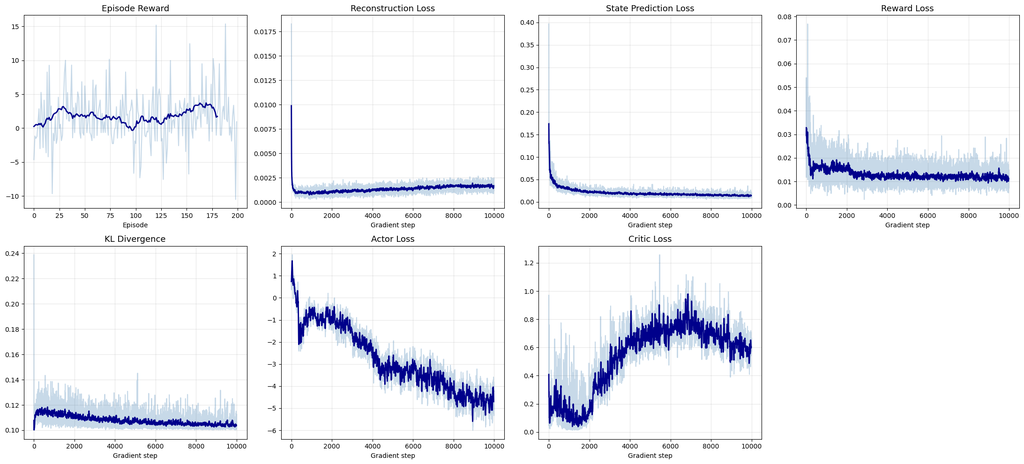

```
Saved training_curves.png
```

```python
def smooth(vals, w=20):
    """Simple moving average for smoother plots."""
    if len(vals) < w:
        return vals
    return np.convolve(vals, np.ones(w)/w, mode='valid')

fig, axes = plt.subplots(2, 4, figsize=(22, 10))
titles = ['Episode Reward', 'Reconstruction Loss', 'State Prediction Loss',
          'Reward Loss', 'KL Divergence', 'Actor Loss', 'Critic Loss']
keys   = ['ep_reward', 'recon', 'state', 'reward', 'kl', 'actor', 'critic']

for ax, title, key in zip(axes.flat[:len(keys)], titles, keys):
    data = log[key]
    ax.plot(data, alpha=0.3, color='steelblue')
    if len(data) > 20:
        ax.plot(smooth(data), color='darkblue', linewidth=2)
    ax.set_title(title, fontsize=13)
    ax.set_xlabel('Episode' if key == 'ep_reward' else 'Gradient step')
    ax.grid(True, alpha=0.3)

# Hide unused subplot
axes.flat[-1].set_visible(False)

plt.tight_layout()
plt.savefig('training_curves.png', dpi=150, bbox_inches='tight')
plt.show()
print('Saved training_curves.png')
```

## 10. Evaluation

We run the trained agent for several episodes **without exploration noise** and record videos of all evaluation episodes, ranked by reward. Both the best checkpoint and the final checkpoint are evaluated and compared.

```python
# Load best checkpoint (saved during training whenever eval reward peaked)
best_ckpt_path = 'dreamer_v1_highway_best.pt'
best_ckpt = torch.load(best_ckpt_path, map_location=DEVICE)
encoder.load_state_dict(best_ckpt['encoder'])
state_encoder.load_state_dict(best_ckpt['state_encoder'])
rssm.load_state_dict(best_ckpt['rssm'])
decoder.load_state_dict(best_ckpt['decoder'])
state_decoder.load_state_dict(best_ckpt['state_decoder'])
reward_model.load_state_dict(best_ckpt['reward'])
actor.load_state_dict(best_ckpt['actor'])
critic.load_state_dict(best_ckpt['critic'])
print(f'Loaded best checkpoint: iter {best_ckpt["iter"]}, eval reward {best_ckpt["mean_reward"]:.2f}')

# Evaluate with the best model
env = make_env()
mean_r, std_r, recorded_frames, ep_rewards = evaluate(env, num_episodes=EVAL_EPISODES, record=True)
env.close()

print(f'Best-model evaluation over {EVAL_EPISODES} episodes:')
print(f'  Mean reward: {mean_r:.2f} +/- {std_r:.2f}')
print(f'  Per-episode rewards: {[f"{r:.1f}" for r in ep_rewards]}')

# Save ALL evaluation videos (ranked by reward)
if recorded_frames:
    ranked = sorted(range(len(ep_rewards)), key=lambda i: ep_rewards[i], reverse=True)
    for rank, idx in enumerate(ranked):
        tag = 'best' if rank == 0 else f'ep{rank+1}'
        vpath = os.path.join(VIDEO_DIR, f'agent_driving_{tag}.mp4')
        imageio.mimsave(vpath, recorded_frames[idx], fps=10)
        print(f'  Video {rank+1}/{len(ranked)}: reward {ep_rewards[idx]:.2f} -> {vpath}')
    # Display the best episode
    best_path = os.path.join(VIDEO_DIR, 'agent_driving_best.mp4')
    display(Video(best_path, embed=True, width=600))
```

```
Loaded best checkpoint: iter 180, eval reward 6.31
```

```
best_ckpt = torch.load(best_ckpt_path, map_location=DEVICE)
```

```
Best-model evaluation over 5 episodes:
  Mean reward: 2.99 +/- 2.58
  Per-episode rewards: ['4.1', '3.0', '7.2', '0.2', '0.5']
```

```
Video 1/5: reward 7.25 -> videos/agent_driving_best.mp4
```

```
Video 2/5: reward 4.07 -> videos/agent_driving_ep2.mp4
```

```
Video 3/5: reward 2.95 -> videos/agent_driving_ep3.mp4
```

```
Video 4/5: reward 0.54 -> videos/agent_driving_ep4.mp4
  Video 5/5: reward 0.16 -> videos/agent_driving_ep5.mp4
```

[video not shown]

```python
# Load the final checkpoint for comparison against the best checkpoint
final_ckpt_path = 'dreamer_v1_highway.pt'
final_ckpt = torch.load(final_ckpt_path, map_location=DEVICE)
encoder.load_state_dict(final_ckpt['encoder'])
state_encoder.load_state_dict(final_ckpt['state_encoder'])
rssm.load_state_dict(final_ckpt['rssm'])
decoder.load_state_dict(final_ckpt['decoder'])
state_decoder.load_state_dict(final_ckpt['state_decoder'])
reward_model.load_state_dict(final_ckpt['reward'])
actor.load_state_dict(final_ckpt['actor'])
critic.load_state_dict(final_ckpt['critic'])
print('Loaded final checkpoint (last training iteration)')

# Evaluate with the final model
env = make_env()
mean_r_final, std_r_final, recorded_frames_final, ep_rewards_final = evaluate(
    env, num_episodes=EVAL_EPISODES, record=True)
env.close()

print(f'Final-model evaluation over {EVAL_EPISODES} episodes:')
print(f'  Mean reward: {mean_r_final:.2f} +/- {std_r_final:.2f}')
print(f'  Per-episode rewards: {[f"{r:.1f}" for r in ep_rewards_final]}')
print(f'  (Best checkpoint reward was: {best_ckpt["mean_reward"]:.2f})')

# Save ALL final-model videos (ranked by reward)
if recorded_frames_final:
    ranked_f = sorted(range(len(ep_rewards_final)), key=lambda i: ep_rewards_final[i], reverse=True)
    for rank, idx in enumerate(ranked_f):
        tag = 'final_best' if rank == 0 else f'final_ep{rank+1}'
        vpath = os.path.join(VIDEO_DIR, f'agent_driving_{tag}.mp4')
        imageio.mimsave(vpath, recorded_frames_final[idx], fps=10)
        print(f'  Video {rank+1}/{len(ranked_f)}: reward {ep_rewards_final[idx]:.2f} -> {vpath}')
    # Display the best final episode
    best_path_f = os.path.join(VIDEO_DIR, 'agent_driving_final_best.mp4')
    display(Video(best_path_f, embed=True, width=600))
```

```
Loaded final checkpoint (last training iteration)
```

```
final_ckpt = torch.load(final_ckpt_path, map_location=DEVICE)
```

```
Final-model evaluation over 5 episodes:
  Mean reward: 7.41 +/- 2.78
  Per-episode rewards: ['5.4', '3.8', '6.8', '9.7', '11.4']
  (Best checkpoint reward was: 6.31)
```

```
Video 1/5: reward 11.35 -> videos/agent_driving_final_best.mp4
```

```
Video 2/5: reward 9.74 -> videos/agent_driving_final_ep2.mp4
```

```
Video 3/5: reward 6.80 -> videos/agent_driving_final_ep3.mp4
```

```
Video 4/5: reward 5.35 -> videos/agent_driving_final_ep4.mp4
  Video 5/5: reward 3.81 -> videos/agent_driving_final_ep5.mp4
```

[video not shown]

## 11. N-Step World-Model Predictions

To evaluate the world model's predictive quality, we:

1. Take a real episode from the replay buffer.
2. **Burn in** the RSSM posterior for a few steps so it builds a good latent state.
3. Switch to **prior-only rollout** — predict the next `N` frames using only the RSSM prior and the actual recorded actions (no new observations).
4. Decode the predicted latent states into images and compare against the actual frames.

```
Using episode with 200 steps
```

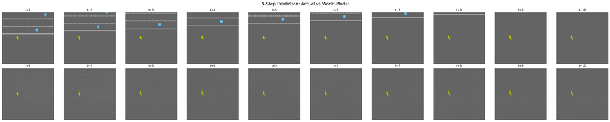

```
Saved prediction_comparison.png
```

```python
@torch.no_grad()
def predict_n_steps(episode, burn_in=5, n_steps=10):
    """
    Compare world-model predictions against ground truth.

    Returns:
        actual_frames   : list of (64,64,3) uint8
        predicted_frames: list of (64,64,3) uint8
    """
    obs = episode['observations']       # (T, 64, 64, 3) uint8
    states = episode['states']          # (T, STATE_DIM) float32
    acts = episode['actions']           # (T-1, 2)
    T = len(acts)

    if burn_in + n_steps > T:
        n_steps = T - burn_in
        if n_steps <= 0:
            return [], []

    h, z = rssm.initial_state(1)

    # ── Burn-in: run posterior with real observations ──
    for t in range(burn_in):
        a = torch.zeros(1, ACTION_DIM, device=DEVICE) if t == 0 else \
            torch.tensor(acts[t-1], dtype=torch.float32, device=DEVICE).unsqueeze(0)
        embed = encode(
            preprocess(obs[t]).unsqueeze(0).to(DEVICE),
            torch.tensor(states[t], dtype=torch.float32, device=DEVICE).unsqueeze(0),
        )
        h, _, _ = rssm.img_step(h, z, a)
        z, _    = rssm.obs_step(h, embed)

    # ── Open-loop prediction: prior only (no observations) ──
    actual_frames, predicted_frames = [], []
    for t in range(burn_in, burn_in + n_steps):
        a = torch.tensor(acts[t-1], dtype=torch.float32, device=DEVICE).unsqueeze(0)
        h, z, _ = rssm.img_step(h, z, a)
        feat = torch.cat([h, z], -1)
        pred_img = decoder(feat).squeeze(0)            # (3, 64, 64)
        predicted_frames.append(postprocess(pred_img))
        actual_frames.append(obs[t])                   # frame predicted by action acts[t-1]

    return actual_frames, predicted_frames


# Find a long episode for good visualisation
long_eps = sorted(buffer.episodes, key=lambda e: len(e['rewards']), reverse=True)
ep = long_eps[0]
print(f'Using episode with {len(ep["rewards"])} steps')

actual, predicted = predict_n_steps(ep, burn_in=5, n_steps=10)
n = len(actual)

if n > 0:
    fig, axes = plt.subplots(2, n, figsize=(3 * n, 6))
    if n == 1:
        axes = axes.reshape(2, 1)
    for i in range(n):
        axes[0, i].imshow(actual[i])
        axes[0, i].set_title(f't+{i+1}', fontsize=10)
        axes[0, i].axis('off')
        axes[1, i].imshow(predicted[i])
        axes[1, i].set_title(f't+{i+1}', fontsize=10)
        axes[1, i].axis('off')
    axes[0, 0].set_ylabel('Actual', fontsize=13)
    axes[1, 0].set_ylabel('Predicted', fontsize=13)
    plt.suptitle('N-Step Prediction: Actual vs World-Model', fontsize=15)
    plt.tight_layout()
    plt.savefig('prediction_comparison.png', dpi=150, bbox_inches='tight')
    plt.show()
    print('Saved prediction_comparison.png')
```

```python
def make_prediction_video(episode, burn_in=5, n_steps=20, path=None):
    """Create a side-by-side video: actual (top) vs predicted (bottom)."""
    actual, predicted = predict_n_steps(episode, burn_in, n_steps)
    if not actual:
        print('Episode too short for prediction video.')
        return

    frames = []
    for a_frame, p_frame in zip(actual, predicted):
        # Scale up for visibility
        a_big = cv2.resize(a_frame, (256, 256), interpolation=cv2.INTER_NEAREST)
        p_big = cv2.resize(p_frame, (256, 256), interpolation=cv2.INTER_NEAREST)
        # Add labels
        a_labeled = a_big.copy()
        p_labeled = p_big.copy()
        cv2.putText(a_labeled, 'ACTUAL', (5, 25),
                    cv2.FONT_HERSHEY_SIMPLEX, 0.8, (255, 255, 255), 2)
        cv2.putText(p_labeled, 'PREDICTED', (5, 25),
                    cv2.FONT_HERSHEY_SIMPLEX, 0.8, (255, 255, 255), 2)
        combined = np.vstack([a_labeled, p_labeled])
        frames.append(combined)

    if path is None:
        path = os.path.join(VIDEO_DIR, 'prediction_comparison.mp4')
    imageio.mimsave(path, frames, fps=5)
    print(f'Prediction video saved: {path}')
    display(Video(path, embed=True, width=400))


# Use the longest episode
make_prediction_video(long_eps[0], burn_in=5, n_steps=20)
```

```
Prediction video saved: videos/prediction_comparison.mp4
```

[video not shown]

## 12. Quantitative Metrics

We measure the world model's prediction quality using:

- **MSE** between predicted and actual frames at each prediction horizon
- **SSIM** (Structural Similarity Index) — perceptual quality metric
- **Reward prediction error** — correlation and MAE between predicted and actual rewards

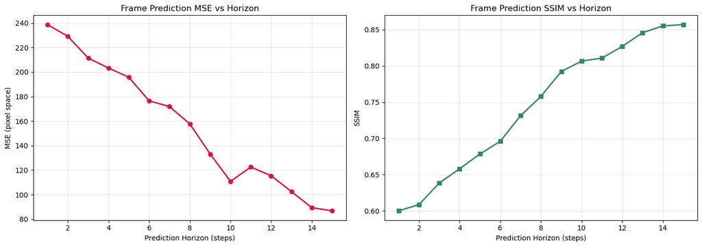

```
Saved prediction_metrics.png

Prediction Quality Summary:
 Horizon        MSE     SSIM
----------------------------
       1      238.7   0.6000
       2      229.1   0.6086
       3      211.4   0.6384
       4      203.2   0.6580
       5      195.8   0.6784
       6      176.4   0.6960
       7      171.8   0.7313
       8      157.7   0.7578
       9      133.1   0.7922
      10      110.8   0.8065
      11      122.5   0.8107
      12      115.4   0.8268
      13      102.4   0.8457
      14       89.3   0.8550
      15       86.7   0.8569
```

```python
from scipy.ndimage import uniform_filter

def ssim_single(img1, img2, window_size=7):
    """Compute SSIM between two (H, W, C) uint8 images."""
    i1 = img1.astype(np.float64)
    i2 = img2.astype(np.float64)
    C1, C2 = (0.01 * 255)**2, (0.03 * 255)**2
    mu1 = uniform_filter(i1, size=(window_size, window_size, 1))
    mu2 = uniform_filter(i2, size=(window_size, window_size, 1))
    s11 = uniform_filter(i1*i1, size=(window_size, window_size, 1)) - mu1*mu1
    s22 = uniform_filter(i2*i2, size=(window_size, window_size, 1)) - mu2*mu2
    s12 = uniform_filter(i1*i2, size=(window_size, window_size, 1)) - mu1*mu2
    ssim_map = ((2*mu1*mu2 + C1) * (2*s12 + C2)) / ((mu1**2 + mu2**2 + C1) * (s11 + s22 + C2))
    return float(ssim_map.mean())


# Evaluate prediction quality at different horizons from the same burn-in state.
# This keeps each horizon comparison on the same rollout instead of mixing different scenes across separate prediction calls.
max_horizon = 15
test_eps = long_eps[:min(5, len(long_eps))]

# Collect per-step errors across episodes
mse_per_step = [[] for _ in range(max_horizon)]
ssim_per_step = [[] for _ in range(max_horizon)]

for ep in test_eps:
    actual, predicted = predict_n_steps(ep, burn_in=5, n_steps=max_horizon)
    for step_idx in range(len(actual)):
        a, p = actual[step_idx], predicted[step_idx]
        mse_per_step[step_idx].append(
            float(np.mean((a.astype(float) - p.astype(float))**2)))
        ssim_per_step[step_idx].append(ssim_single(a, p))

# Average across episodes for each horizon
horizons = list(range(1, max_horizon + 1))
mse_by_h = [np.mean(vals) if vals else 0 for vals in mse_per_step]
ssim_by_h = [np.mean(vals) if vals else 0 for vals in ssim_per_step]

# Plot
fig, (ax1, ax2) = plt.subplots(1, 2, figsize=(14, 5))
ax1.plot(horizons, mse_by_h, 'o-', color='crimson', linewidth=2)
ax1.set_xlabel('Prediction Horizon (steps)')
ax1.set_ylabel('MSE (pixel space)')
ax1.set_title('Frame Prediction MSE vs Horizon')
ax1.grid(True, alpha=0.3)

ax2.plot(horizons, ssim_by_h, 's-', color='seagreen', linewidth=2)
ax2.set_xlabel('Prediction Horizon (steps)')
ax2.set_ylabel('SSIM')
ax2.set_title('Frame Prediction SSIM vs Horizon')
ax2.grid(True, alpha=0.3)

plt.tight_layout()
plt.savefig('prediction_metrics.png', dpi=150, bbox_inches='tight')
plt.show()
print('Saved prediction_metrics.png')

# Summary table
print('\nPrediction Quality Summary:')
print(f'{"Horizon":>8} {"MSE":>10} {"SSIM":>8}')
print('-' * 28)
for h, mse, ssim in zip(horizons, mse_by_h, ssim_by_h):
    print(f'{h:>8} {mse:>10.1f} {ssim:>8.4f}')
```

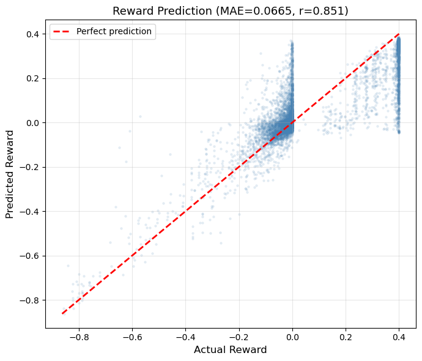

```
Reward MAE: 0.0665,  Correlation: 0.851
```

```python
@torch.no_grad()
def evaluate_reward_prediction(buffer, num_batches=10):
    """Measure how well the reward model predicts actual rewards."""
    all_actual, all_pred = [], []
    for _ in range(num_batches):
        batch = buffer.sample(BATCH_SIZE, SEQ_LEN)
        obs, states, actions, rewards = (batch['obs'], batch['states'],
                                          batch['actions'], batch['rewards'])
        B, L = actions.shape[:2]

        embeds = encode(
            obs.reshape(B*L, 3, IMG_SIZE, IMG_SIZE),
            states.reshape(B*L, STATE_DIM),
        ).reshape(B, L, EMBED_DIM)
        zero_a = torch.zeros(B, 1, ACTION_DIM, device=DEVICE)
        shifted = torch.cat([zero_a, actions[:, :-1]], 1)
        _, _, _, _, h_s, z_s = rssm.observe(embeds, shifted)
        feat = torch.cat([h_s, z_s], -1).reshape(B*L, FEAT_DIM)
        pred = reward_model(feat).reshape(B, L)

        # Arrival convention: features[t] predicts rewards[t-1], features[0] predicts 0
        zero_r = torch.zeros(B, 1, device=DEVICE)
        arrival_rewards = torch.cat([zero_r, rewards[:, :-1]], dim=1)
        all_actual.append(arrival_rewards.cpu().numpy().flatten())
        all_pred.append(pred.cpu().numpy().flatten())

    actual = np.concatenate(all_actual)
    pred   = np.concatenate(all_pred)

    # MAE measures absolute prediction error, while correlation checks whether
    # the reward model preserves the overall reward ordering/trend.
    mae = np.mean(np.abs(actual - pred))
    corr = np.corrcoef(actual, pred)[0, 1] if len(actual) > 1 else 0.0

    fig, ax = plt.subplots(figsize=(7, 6))
    ax.scatter(actual, pred, alpha=0.1, s=5, color='steelblue')
    lims = [min(actual.min(), pred.min()), max(actual.max(), pred.max())]
    ax.plot(lims, lims, 'r--', linewidth=2, label='Perfect prediction')
    ax.set_xlabel('Actual Reward', fontsize=12)
    ax.set_ylabel('Predicted Reward', fontsize=12)
    ax.set_title(f'Reward Prediction (MAE={mae:.4f}, r={corr:.3f})', fontsize=13)
    ax.legend()
    ax.grid(True, alpha=0.3)
    plt.tight_layout()
    plt.savefig('reward_prediction.png', dpi=150, bbox_inches='tight')
    plt.show()
    print(f'Reward MAE: {mae:.4f},  Correlation: {corr:.3f}')
    return mae, corr

rew_mae, rew_corr = evaluate_reward_prediction(buffer)
```

## 13. Analysis and Conclusions

This notebook run shows that the Dreamer-style agent learned both a usable world model and a policy that performs meaningfully better by the end of training.

### Key results

- Final reconstruction loss: **0.0014**
- Final state prediction loss: **0.0166**
- Final KL loss: **0.11**
- Reward prediction: **MAE = 0.0665**, **correlation = 0.851**
- Best-checkpoint post-hoc evaluation: **2.99 ± 2.58**
- Final-checkpoint post-hoc evaluation: **7.41 ± 2.78**

### Interpretation

The low reconstruction and state losses indicate that the latent feature preserves both the visual highway scene and the auxiliary heading/speed information. The KL staying slightly above the free-nats floor suggests that the stochastic latent state is being used, but the environment is structured enough that it does not need a large stochastic capacity.

The final checkpoint outperforming the best saved checkpoint in post-training evaluation is most likely due to environment variance and the small evaluation sample size (5 episodes per checkpoint), rather than a contradiction in training.

For n-step prediction, MSE decreases and SSIM increases with horizon in this evaluation set. This should not be interpreted as long-horizon prediction being intrinsically easier. In these episodes, later frames became visually simpler because the ego vehicle moved ahead of the initial traffic cluster.

### Important design choices

This implementation extends vanilla Dreamer V1 with:

- an auxiliary state branch `[speed_norm, cos(heading), sin(heading)]`
- a `StateDecoder` loss to reinforce heading/speed information in the latent
- a heading-alignment reward wrapper to reduce spinning behavior

### Limitations

- 64x64 images remove fine spatial detail
- data collection is sequential rather than parallel
- the discount factor is fixed rather than learned
- exploration uses simple Gaussian action noise

The full detailed discussion is provided in the final report.

```python
# Final summary
print('=' * 60)
print('TRAINING SUMMARY')
print('=' * 60)
print(f'CNN depth:                  {CNN_DEPTH}')
print(f'Embed dim:                  {EMBED_DIM} (CNN {CNN_EMBED} + State {STATE_EMBED})')
print(f'Feat dim:                   {FEAT_DIM}')
print(f'Free nats:                  {FREE_NATS}')
print(f'Mean scale:                 {Actor.MEAN_SCALE}')
print(f'Exploration noise:          {EXPL_NOISE}')
print(f'Steer penalty:              {STEER_PENALTY}')
print(f'Max steer:                  {MAX_STEER}')
print(f'Batch size:                 {BATCH_SIZE}')
print(f'Sequence length:            {SEQ_LEN}')
print(f'Total training iterations:  {TRAIN_ITERS}')
print(f'Gradient steps per iter:    {TRAIN_STEPS}')
print(f'Total gradient steps:       {TRAIN_ITERS * TRAIN_STEPS:,}')
print(f'Buffer size:                {len(buffer):,} transitions')
print(f'Best-model eval reward:     {mean_r:.2f} +/- {std_r:.2f}')
print(f'Final-model eval reward:    {mean_r_final:.2f} +/- {std_r_final:.2f}')
if eval_log['mean_reward']:
    print(f'Best eval reward:           {max(eval_log["mean_reward"]):.2f}')
print(f'Final recon loss:           {log["recon"][-1]:.4f}')
print(f'Final state loss:           {log["state"][-1]:.4f}')
print(f'Final KL loss:              {log["kl"][-1]:.2f}')
print(f'Reward prediction MAE:      {rew_mae:.4f}')
print(f'Reward prediction corr:     {rew_corr:.3f}')
print('=' * 60)
```

```
============================================================
TRAINING SUMMARY
============================================================
CNN depth:                  48
Embed dim:                  1600 (CNN 1536 + State 64)
Feat dim:                   230
Free nats:                  0.1
Mean scale:                 2.0
Exploration noise:          0.05
Steer penalty:              0.5
Max steer:                  0.3
Batch size:                 32
Sequence length:            25
Total training iterations:  200
Gradient steps per iter:    50
Total gradient steps:       10,000
Buffer size:                18,917 transitions
Best-model eval reward:     2.99 +/- 2.58
Final-model eval reward:    7.41 +/- 2.78
Best eval reward:           6.31
Final recon loss:           0.0014
Final state loss:           0.0166
Final KL loss:              0.11
Reward prediction MAE:      0.0665
Reward prediction corr:     0.851
============================================================
```